# R HW 02

Author

Robsen Gelalcha

Published

September 8, 2026

```r
library(tidyverse)
library(palmerpenguins)
```

# Exercise 1

```r
patients_raw <- read_csv("data/patients.csv")
glimpse(patients_raw)
```

```
Rows: 30
Columns: 4
$ patient_id     <chr> "P001", "P002", "P003", "P004", "P005", "P006", "P007",…
$ gender_code    <chr> "1", "0", "0", "1", "1", "1", "1", "0", "1", "0", "1", …
$ baseline_score <chr> "6", "6", "5", "8", "10", "14", "11", "8", "10", "8", "…
$ followup_score <dbl> 11, 9, 11, 12, 13, 11, 14, 16, 18, 13, 16, 10, 10, 12, …
```

# Exercise 2

- There are 30 rows, which represent observations. There are 4 coulmns, which represent variables.
- A single row represents a patient.
- R interpreted the `gender_code` and `baseline_score` as characters even though their non-missing values are numerical codes and scores. This occurred because their missing values are represented with characters.
- Because a typical data-analysis workflow involves inspecting structure and contents and cleaning the data as necessary.

```r
glimpse(patients_raw) # this displays number of rows and columns.
```

```
Rows: 30
Columns: 4
$ patient_id     <chr> "P001", "P002", "P003", "P004", "P005", "P006", "P007",…
$ gender_code    <chr> "1", "0", "0", "1", "1", "1", "1", "0", "1", "0", "1", …
$ baseline_score <chr> "6", "6", "5", "8", "10", "14", "11", "8", "10", "8", "…
$ followup_score <dbl> 11, 9, 11, 12, 13, 11, 14, 16, 18, 13, 16, 10, 10, 12, …
```

# Exercise 3

- `gender_code` and `baseline_code` changed type because we’ve told R to identify its two character values as NA.
- It didn’t change the number rows and columns. Change in type does not reduce or add number of observations and variables.
- `gender_code` is a qualitative measurement. Even though it’s numerical, they’re discrete values that alternate between `1`’s and `0`’s.
- A variables being a numeric values doesn’t necesarily mean that it represents a quantitative value.

```r
patients <- read_csv("data/patients.csv",na = c("Not recorded","."))
glimpse(patients)
```

```
Rows: 30
Columns: 4
$ patient_id     <chr> "P001", "P002", "P003", "P004", "P005", "P006", "P007",…
$ gender_code    <dbl> 1, 0, 0, 1, 1, 1, 1, 0, 1, 0, 1, NA, 0, 1, 1, 0, 0, 0, …
$ baseline_score <dbl> 6, 6, 5, 8, 10, 14, 11, 8, 10, 8, 10, 9, 4, 8, 8, 9, NA…
$ followup_score <dbl> 11, 9, 11, 12, 13, 11, 14, 16, 18, 13, 16, 10, 10, 12, …
```

```r
summary(patients)
```

```
  patient_id         gender_code     baseline_score   followup_score
 Length:30          Min.   :0.0000   Min.   : 3.000   Min.   : 6
 Class :character   1st Qu.:0.0000   1st Qu.: 7.000   1st Qu.:10
 Mode  :character   Median :0.0000   Median : 8.000   Median :12
                    Mean   :0.4138   Mean   : 8.069   Mean   :12
                    3rd Qu.:1.0000   3rd Qu.:10.000   3rd Qu.:13
                    Max.   :1.0000   Max.   :14.000   Max.   :19
                    NA's   :1        NA's   :1
```

# Exercise 4

```r
score_change <- c(patients$followup_score - patients$baseline_score)
t.test(score_change, mu = 0)
```

```
    One Sample t-test

data:  score_change
t = 7.2646, df = 28, p-value = 6.575e-08
alternative hypothesis: true mean is not equal to 0
95 percent confidence interval:
 2.971159 5.304703
sample estimates:
mean of x
 4.137931
```

```r
#Consulted Claude Opus 4.8 for assistance for above t test.
#Chat can be accessed here: https://claude.ai/share/8623d47a-8c3b-4890-8731-b758ca210aa2
```

$H_0: \mu_{diff} = 0$

$H_A: \mu_{diff} \neq 0$

$\alpha = 0.01$

```r
# patients <- read_csv("data/patients.csv",na = c("Not recorded","."))
score_change <- c(patients$followup_score - patients$baseline_score)

print(score_change)
```

```
 [1]  5  3  6  4  3 -3  3  8  8  5  6  1  6  4  7 -2 NA  6  6  9  5  8  0  7  1
[26]  5  0  1  3  5
```

```r
print(score_change[5])
```

```
[1] 3
```

```r
class(score_change)
```

```
[1] "numeric"
```

```r
summary(score_change)
```

```
   Min. 1st Qu.  Median    Mean 3rd Qu.    Max.    NA's
 -3.000   3.000   5.000   4.138   6.000   9.000       1
```

```r
print(mean(score_change,na.rm = TRUE))
```

```
[1] 4.137931
```

```r
print(median(score_change, na.rm = TRUE))
```

```
[1] 5
```

```r
print(min(score_change, na.rm = TRUE))
```

```
[1] -3
```

```r
print(max(score_change, na.rm = TRUE))
```

```
[1] 9
```

```r
sum(score_change < 0, na.rm = TRUE) # number of patients with declined scores
```

```
[1] 2
```

# Exercise 5

```r
write_csv(patients, "data/patients_clean.csv")
patients_check <- read_csv("data/patients_clean.csv")
print(dim(patients) == dim(patients_check))
```

```
[1] TRUE TRUE
```

```r
glimpse(patients_check)
```

```
Rows: 30
Columns: 4
$ patient_id     <chr> "P001", "P002", "P003", "P004", "P005", "P006", "P007",…
$ gender_code    <dbl> 1, 0, 0, 1, 1, 1, 1, 0, 1, 0, 1, NA, 0, 1, 1, 0, 0, 0, …
$ baseline_score <dbl> 6, 6, 5, 8, 10, 14, 11, 8, 10, 8, 10, 9, 4, 8, 8, 9, NA…
$ followup_score <dbl> 11, 9, 11, 12, 13, 11, 14, 16, 18, 13, 16, 10, 10, 12, …
```

- Checking an exported file by importing and verifying it enables us to analyse the same data across different devices without hiccups like making sure it’s in the right location.

# Exercise 6

```r
library(palmerpenguins)
glimpse(penguins)
```

```
Rows: 344
Columns: 8
$ species           <fct> Adelie, Adelie, Adelie, Adelie, Adelie, Adelie, Adel…
$ island            <fct> Torgersen, Torgersen, Torgersen, Torgersen, Torgerse…
$ bill_length_mm    <dbl> 39.1, 39.5, 40.3, NA, 36.7, 39.3, 38.9, 39.2, 34.1, …
$ bill_depth_mm     <dbl> 18.7, 17.4, 18.0, NA, 19.3, 20.6, 17.8, 19.6, 18.1, …
$ flipper_length_mm <int> 181, 186, 195, NA, 193, 190, 181, 195, 193, 190, 186…
$ body_mass_g       <int> 3750, 3800, 3250, NA, 3450, 3650, 3625, 4675, 3475, …
$ sex               <fct> male, female, female, NA, female, male, female, male…
$ year              <int> 2007, 2007, 2007, 2007, 2007, 2007, 2007, 2007, 2007…
```

```
Warning: Removed 2 rows containing missing values or values outside the scale range
(`geom_point()`).
```

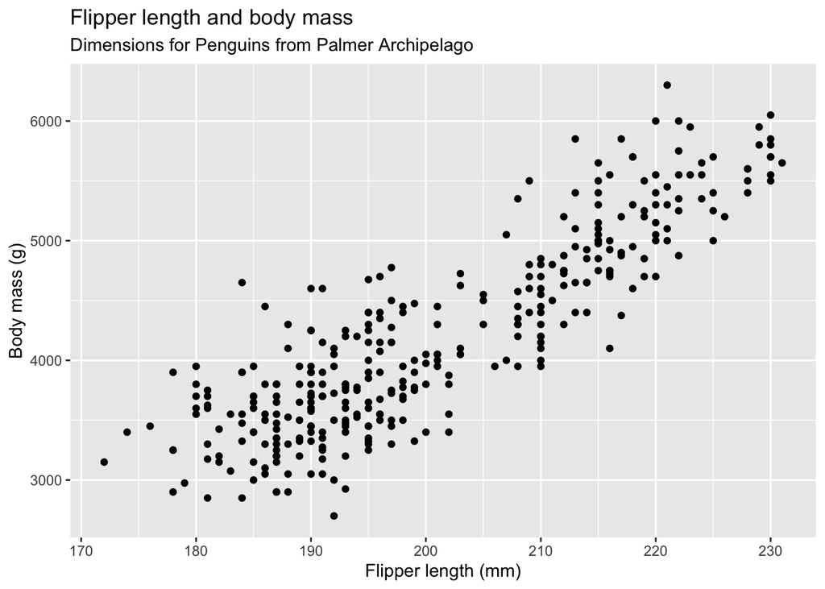

```r
ggplot(data = penguins,
       mapping = aes(x = flipper_length_mm, y = body_mass_g)) +
  geom_point() +
  labs(title = "Flipper length and body mass",
       subtitle = "Dimensions for Penguins from Palmer Archipelago",
       x = "Flipper length (mm)", y = "Body mass (g)")
```

- There is a positive linear relationship between Body mass and Flipper length.
- R produced a warning. It alerts that 2 rows containing missing values or outside the scale range were removed.

# Exercise 7

```
Warning: Removed 2 rows containing missing values or values outside the scale range
(`geom_point()`).
```

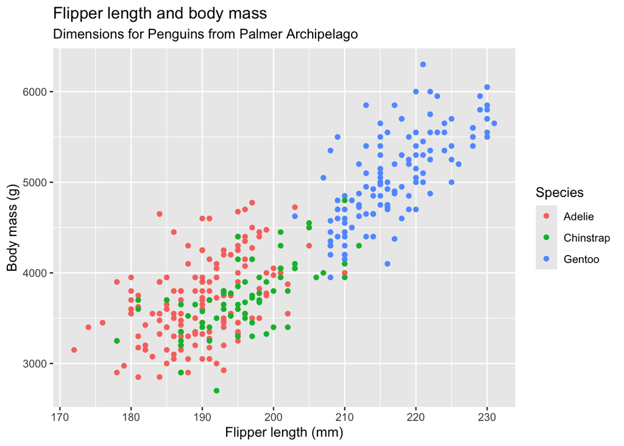

```r
penguin_data <- penguins
species_factor <- factor(penguins$species)
ggplot(data = penguins,
       mapping = aes(x = flipper_length_mm, y = body_mass_g, color = species)) +
  geom_point() +
  labs(title = "Flipper length and body mass",
       subtitle = "Dimensions for Penguins from Palmer Archipelago",
       x = "Flipper length (mm)", y = "Body mass (g)", color = "Species")
```

- The color reveals that Gentoo penguins are have overall higher body mass and flipper length than Adelle and Chinstrap penguins.
- Yes, the overall the relationship between the two variables is made more pronounced with the addition of gentoo penguins
- color is mapped to a variable. The mapping is inside `aes`.

# Exercise 8

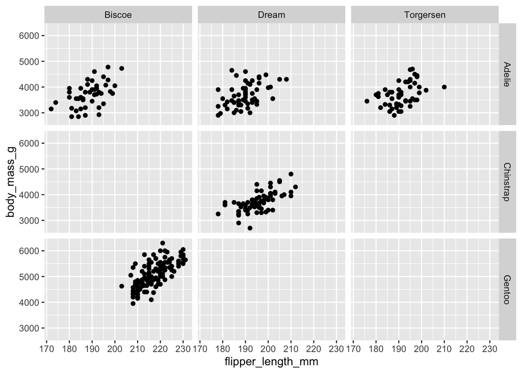

```r
ggplot(penguins, aes(x = flipper_length_mm, y = body_mass_g)) +
  geom_point() +
  facet_grid(species ~ island)
```

- It’s easier to see the overall relationship between the two variables on the color coded plot
- It’s easier to see the relationship between flipper length and body mass within a species
- I’d use the color-coded plot. If my goal is to communicate the relationship between all three variables, the color-coded one does a better job at displaying a more linear relationship and isn’t specific to one species.

# Exercise 9

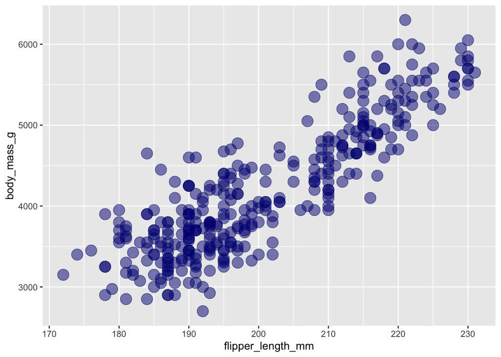

```r
ggplot(
  penguins,
  aes(
    x = flipper_length_mm,
    y = body_mass_g,

  )
) +
  geom_point(color = "navyblue", alpha=0.5, size = 5)
```

# Reflection prompts

*Respond to each of the following after you have completed all exercises in this assignment*

*(RP1): What were the main concepts covered in this assignment?*

- Data visualization, Importing data and exporting data, Summary Statistics, Dealing with missing data, Statistical inference, Data analysis workflow, Aesthetics, Mapping and Setting, Faceting.

*(RP2): What’s one thing you understand better or can do more confidently after completing these exercises?*

- Creating simple scatter-plots in R.

*(RP3): Where did you experience the most difficulty or uncertainty? Describe where you got stuck, what you tried, and what ultimately helped—or what remains unresolved.*

- I had to revise on doing t tests and determining null and alternative hypothesis. I consulted an LLM.